# Coursework Report

*N* removed NAs: 3

*N* removed typo: 1

*N* total clean: 127

[output not shown]

**Main analysis results**

*t*(125) = -8.28, *p* < .001

[interactive chart not shown]

[figure not shown]

[interactive chart not shown]

# Coursework Report

Analysing Data, Spring 2020

This student has a record of specific learning difficulty (dyslexia/dyspraxia). Please mark this report in accordance with the [marking guidelines for SLD](https://www.sussex.ac.uk/studentsupport/staff/spld?fbclid=IwAR2lYKD6xvuv9egQDvG8d_oed9GUD3KXQn3gAdlHZ1gQB8gDddBdeOEmKdE).

# Methods

## Participants

150 participants took part in the experiment initially. However, I removed 19 participants from my reporting of the results due to them being under the age of 18, 1 for incorrectly inputed data (had age as ‘1e’) and 3 for not provding their age (NA). My analysis will therefore be done using the results from the remaining 127 participants.

### Descriptive Statistics for age of paricipants

Mean: 20.76 Median: 20 Range:18 to 28

## Design

For this experiment, the conceptual hypothesis we were looking to investigate was; do the colours red and white have an effect on womens perception of mens attractiveness?

All participants were shown the same black and white image of a moderately attractive Caucasion man, they viewed this image with a 4.5x5" border that was either white (control group) or red (experimental group).

We operationalised percieved attractiveness by asking participants 3 questions after seeing the image to be answered with a score on a 9-point likert scale (e.g. 1 being not at all attractive, to 9 being extremely attractive). We then averaged the scores to create a composite score. The questions were as follows; ‘How attractive do you think this person is?’, ‘How pleasant is this person to look at?’ and ‘If I were to meet this person face to face, I would think he is attractive.’

Participants in the experimental group will provide a higher composite score of percieved attractiveness due to the red border on the image. To test this hypothesis I will conduct an independent measures t-test within my statistical analysis.

# Results

The following graph shows the means (with standard error bars) for both the control and experimental groups.

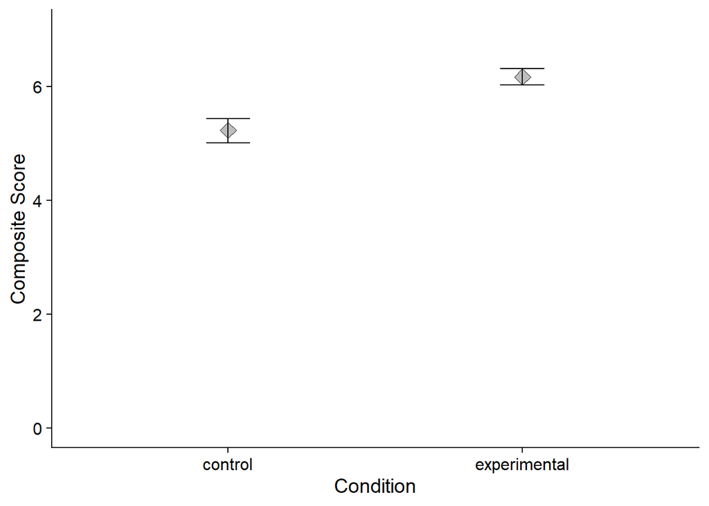

Since the *p* score is small (0), which means that is it very unlikely that the two sample means are from the same population and therefore we will reject the null hypothesis. Instead, we conclude that they may come from different populations. In this case, the “two different populations” would be “people who gave an attractiveness rating based on the photo with a white background” and “people who gave an attractiveness rating based on the photo with a red background”.

In short, the result of the analysis suggests that whether a participant was presented with the photo on a red or white background does influence their attractiveness ratings of the same person photographed.

# Discussion

The results of the *t*-test show a statiatically significantly difference between the means of the control and experimental group. This along with a very low *p* score means it is not likely that the sample means have come from the same population. The results of the analysis of this study suggest that colour does have an effect on composite attraction scores.

## Implications

The original study Elliot et al., (2010) also found that the composite attraction scores were higher in the experimental (red) group than in the control (white) group. My study’s results support the original findings, which suggests a level of reliability. However, other studies exploring the ‘red effect’ have had mixed results. Some studys such as Pazda et al., (2012) have found results that also support the original study, although this study looked at the ‘red effect’ from the perspective of males looking at females. Elliot replicated his own study with a larger sample size and found the results to be statistically insignificant (Elliot & Maier, 2013). Another study that explored the ‘red effect’ but asked questions from the perspectives from two scenarios, short and long term dating, was conducted by (Peperkoorn et al., 2016). The adding of the two scenarios gave a way of measuring the motivation of the male participants. The results of this study failed to be consistent with the predictions that the woman in red would be percieved to be more sexually attractive. The woman in red wasn’t percieved to be more sexually attractive, or more attractive in any other way compared to the other women. These inconsistencies amongst various studies into the ‘red effect’ give an insight into the general picture amongst literature on the subject. Attraction is a very complex concept as it doesn’t just come from innate cues, but is also heavily influenced by social cues. This could bring up questions as to how we should measure the ‘red effect’ effectively and if we have been measuring it in a valid way up until now.

## Limitations

To build on my previous comment on the complexity of ‘attraction’ as a concept, things such as social cues must be taken into account when looking at results of studies of this nature. It could be, therefore, that my study may be an oversimplification of the concept, and not measure attraction as holistically as it could. The study is clearly replicable, but that doesn’t mean it is measuring the variables effectively. I also think that it is worth commenting on sample size. Both in the original study, and my own replication, these sample sizes arent really large enough to repreent a whole population. In fact, when looking at the results of the Elliot and Maier (2013) study, this is clear to see. It was a direct replication of Elliot’s 2010 study in everyway except sample size, yet the results were not the same.

## Further Research

Amongst the inconsistencies, there is some of empirical evidence for the existence of the ‘red effect’. There are not, however, many conclusions about the origin of the ‘red effect’. Further research could be done to look further into where the ‘red effect’ comes from either biologically or socially. To look into whether it is a social influence, the original study could be replicated in larger sample sizes in different parts of the world. What is considered attractive varies culturally and consisitent results supporting the prediction that the colour red influences attraction to produce higher attraction compotite scores across different cultures could suggest that the ‘red effect’ is of a more biologically innate origin. My replication study also only looked at a relatively small range of ages (18-28). Further research could be done to compare the ‘strength’ of the effect the colour red has on percieved sttraction between age groups. For this to be valuable, looking at differences in hormone level across the age ranges, as well as where the participants are in their menstrual cycle may also lead to more in depth conclusions about the origin fo the effect. In conclusion, the results of my study support the existance of the ‘red effect’, however, there are inconsitencies among other literature on the subject. This suggests to me that it may have been an oversimplification of the concept of ‘attraction’, and more varied scenarios need to be researched.

# References

Elliot, A. J., & Maier, M. A. (2013). The red-attractiveness effect, applying the Ioannidis and Trikalinos (2007b) test, and the broader scientific context: A reply to Francis (2013). Journal of Experimental Psychology: General, 142(1), 297–300. https://doi.org/10.1037/a0029592

Elliot, A. J., Niesta Kayser, D., Greitemeyer, T., Lichtenfeld, S., Gramzow, R. H., Maier, M. A., & Liu, H. (2010). Red, rank, and romance in women viewing men. Journal of Experimental Psychology: General, 139(3), 399–417. https://doi.org/10.1037/a0019689

Pazda, A. D., Elliot, A. J., & Greitemeyer, T. (2012). Sexy red: Perceived sexual receptivity mediates the red-attraction relation in men viewing woman. Journal of Experimental Social Psychology, 48(3), 787–790. https://doi.org/10.1016/j.jesp.2011.12.009

Peperkoorn, L. S., Roberts, S. C., & Pollet, T. V. (2016). Revisiting the Red Effect on Attractiveness and Sexual Receptivity: No Effect of the Color Red on Human Mate Preferences. Evolutionary Psychology, 14(4), 147470491667384. https://doi.org/10.1177/1474704916673841